# R Notebook -‘Good’ Programming Practices

# Good defined

- programming is an art based on how your brain works.
- I think about things as functions with inputs and outputs
- sometimes you won’t have an output
- sometimes you will have default values for inputs
- coding standards may need to be applied. I am a WHITESMITH guy.
- the faster I can read OLD code, the better.
- the less the brain has to “translate” information, the more efficient coding becomes

## foo

```r
foo = function(x)
  {
  3*x^2 - 2*x;  # by default, the last line of a function is returned.
  }
```

```r
foo(1:10);  # outputs to the console
```

```
 [1]   1   8  21  40  65  96 133 176 225 280
```

```r
invisible( foo(1:10) );  # executes but doesn't automatically output to the console
```

```r
res = foo(1:10);  # notice left/right hand notation common for functions ... assigned to variable res
```

```r
res;
```

```
 [1]   1   8  21  40  65  96 133 176 225 280
```

- when scaling, efficiency still matters

```r
X = sample(10);  # notice "X" is not "x"
X;
```

```
 [1]  8  6  7  4  3  9  1  2 10  5
```

## sample

“sample is horribly inefficient”. Let’s think about C-programming, what is the fundamental function?

```r
# rand(1,2);
```

where is this function? why doesn’t it exist in “base R”? That is a sign that “base R” doesn’t follow many standard software-engineering protocols or practices. ARGH!

Maybe we should just write the function?

### rand

```r
rand = function(min = -1*as.integer(Sys.time()), max = as.integer(Sys.time()), n = 1, method = "high-low", sample.replace = TRUE, seed = NULL, attributes=NULL)
    {
    # if(is.null(seed)) { setSeed(NULL, "rand"); my.seed = getSeed("rand"); } else { my.seed = seed; }
    me = substr( trimMe( tolower(method) ), 1, 2);
    n = as.integer ( n );
    if(is.na(n) || n < 1)
        {
        warning( paste0('Bad value for n "', n, '" in function [rand]', "\n", "Setting n=1") );
        n = 1;
        }
    res = NULL;
    if(me == "hi")  # high-low method
      {
      if(!is.null(seed)) { set.seed(seed); }
      res = ( as.integer(( (max + 1) - min) * stats::runif(n) + min) );
      }
    else if(me == "fl")  # floor method
      {
      if(!is.null(seed)) { set.seed(seed); }
      res = ( as.integer( floor( stats::runif(n, min = min, max = (max + 1) ) ) ) );
      }
    else if(me == "sa")  # sample method
      {
      if(!sample.replace)
        {
        len = (max - min) + 1;
        if(len < n)
          {
          warning( "sample.replace forced to TRUE" );
          sample.replace = TRUE;
          }
        }
      if(!is.null(seed)) { set.seed(seed); }
      res = ( sample(min:max, n, replace = sample.replace) );
      }
    else
        {
    stop( paste0('Unknown method "', method, '" in function [rand]') );
        }

    if(!is.null(attributes))
        {
        res = setAttribute('min', min, res);
        res = setAttribute('max', max, res);
        res = setAttribute('seed', seed, res);
        res = setAttribute('method', method, res);
        }

    res;
    }
```

### rand documentation

When you write a function, you should think about the use cases and program accordingly. Some documentation is also helpful.

```r
#' rand
#'
#' Generate random integers between two values (min, max).
#'
#' @param min By default -1*as.integer(Sys.time()), what is the minimum?  Could be negative.
#' @param max By default as.integer(Sys.time()), what is the maximum?
#' @param n By default 1, how many random elements do you want?
#' @param method By default "high-low" which slightly outperforms "floor" which both outperform "sample"
#' @param seed By default NULL, meaning we are not worried about tracking the seed here.
#' @param sample.replace For method "sample", will allow replace = FALSE (make certain n, min/max are comformable for this)
#'
#' @return
#' @export
#'
#' @examples
#' rand();            # positive or negative integer
#' rand(1);           # positive integer only
#' rand(1, n=3);      # returns 3 positive integers
#' rand(1,10, n=5, method="floor");  # Uses the floor method
#' rand(1,10, n=5, method="sample"); # Uses the sample method (available, but why?)
#' rand(1,10, n=5, method="sample", sample.replace=FALSE); # min, max, n must be comformable "with replacement = FALSE"
#' rand(1,10, n=5, seed=10);  # fixed seed requires the min/max to be known
```

The structure of the documentation is compatible with building a library of functions (to be further discussed).

```r
rand();
```

```
[1] 1099237746
```

## Support Functions

### trimMe

```r
trimMe = function(str, side="both", method="stringi")
  {
  # sides = c("both", "left", "right")
  side = tolower(side);
  # stringr::str_trim(str);
  # if(!is.element(side,sides)) { stop("option for 'side' must be one of:  both, left, right"); }
  # set default to both

  # dump stringr and go to stringi
  # dump tidyverse altogether
  # review httr and build appropriate functions
  # use base whenever possible, then the best packages whenever possible
  # define best by "least associated with new grammar tactics"
  # new grammar is arbitrary and not c-based
  # human-readable functions with variadic inputs is not new grammar
# lsf.str("package:stringi")
# ls("package:stringi")

  if( isTRUE(requireNamespace("stringi", quietly = TRUE)) && method=="stringi" )
    {
    switch(side,
          "left"  = stringi::stri_trim_left(str),
          "right" = stringi::stri_trim_right(str),
          "both"  = stringi::stri_trim_both(str),
          stringi::stri_trim_both(str)
          );
    } else {
            switch(side,
                  "left"  = gsub("^\\s+", "", str),
                  "right" = gsub("\\s+$", "", str),
                  "both"  = gsub("^\\s+|\\s+$", "", str),
                  gsub("^\\s+|\\s+$", "", str)
                  );
            }
  }
```

This code relies on a library (“stringi”) which is written in C (which means it is fast). If the library and its method are not found, it uses the ‘gsub’ function of the base. **NO TIDYVERSE HERE** Not TIDY and not VERSE

### setAttribute(s)

I also need a setAttribute function

```r
setAttribute = function(myAttribute, myValue, myObj)
    {
    attributes(myObj)[[myAttribute]] = myValue;
    myObj;  # no object referencing, so I must return
    }

#' setAttributes
#'
#' @param myAttributes
#' @param myValues
#' @param myObj
#'
#' @return
#' @export
#'
#' @examples
# set.attributes
setAttributes = function(myAttributes, myValues, myObj)
    {
    i = 0;
    for(myAttribute in myAttributes)
        {
        i = 1 + i;
        # what if myValue is an array?
        myValue = myValues[[i]]; # we assume they are of equal length, could error check
        if(length(myValue) > 0)
            {
            if(!is.na(myValue))
                {
                attributes(myObj)[[myAttribute]] = myValue;
                }
            }
        }
    myObj;  # no object referencing, so I must return
    }
```

This is an example where R is using some other “functional” method other than INPUT –> OUTPUT.

So I have written a function that is of the form INPUT–>OUTPUT

# rand()

```r
rand();
```

```
[1] 491891858
```

We now have a ‘rand’ function. We can test the different parameters.

## parameters

```r
 rand();            # positive or negative integer
```

```
[1] 1111340138
```

```r
 rand(1);           # positive integer only
```

```
[1] 485939258
```

```r
 rand(1, n=3);      # returns 3 positive integers
```

```
[1] 1324237294  696057354  282690054
```

```r
 rand(1,10, n=5, method="floor");  # Uses the floor method
```

```
[1]  4  7 10  3  9
```

```r
 rand(1,10, n=5, method="sample"); # Uses the sample method (available, but why?)
```

```
[1]  9  6  9  6 10
```

```r
 rand(1,10, n=5, method="sample", sample.replace=FALSE); # min, max, n must be comformable "with replacement = FALSE"
```

```
[1] 10  5  9  6  3
```

```r
 rand(1,10, n=5, seed=10);  # fixed seed requires the min/max to be known
```

```
[1] 6 4 5 7 1
```

Notice the last result, with a fixed seed = 10, the numbers do not change. This is important when you want to randomize something, share it with another person, and have the same random data used when you finish.

## Benchmarks

So which is most efficient, first let’s look at the code. ‘runif’ is the basic engine of randomness here (and in most places)… Uniform random …

```r
library(microbenchmark);
microbenchmark::microbenchmark(
         rand(),            # positive or negative integer
         rand(1),           # positive integer only
         rand(1, n=3),      # returns 3 positive integers
         rand(1,10, n=5, method="floor"),  # Uses the floor method
         rand(1,10, n=5, method="sample"), # Uses the sample method (available, but why?)
         rand(1,10, n=5, method="sample", sample.replace=FALSE), # min, max, n must be comformable "with replacement = FALSE"
         rand(1,10, n=5, seed=10)
        )
```

```
Unit: microseconds
```

| expr | min | lq | mean | median | uq | max | neval | cld |
| --- | --- | --- | --- | --- | --- | --- | --- | --- |
| rand() | 99.4 | 102.25 | 126.556 | 104.70 | 114.85 | 460.0 | 100 | b |
| rand(1) | 85.3 | 88.65 | 113.475 | 91.00 | 103.40 | 267.9 | 100 | b |
| rand(1, n = 3) | 87.7 | 90.35 | 112.848 | 93.10 | 100.10 | 393.6 | 100 | ab |
| rand(1, 10, n = 5, method = "floor") | 70.3 | 75.60 | 93.374 | 78.35 | 86.50 | 285.3 | 100 | a |
| rand(1, 10, n = 5, method = "sample") | 80.6 | 86.15 | 108.664 | 88.60 | 101.30 | 315.1 | 100 | ab |
| rand(1, 10, n = 5, method = "sample", sample.replace = FALSE) | 86.3 | 92.40 | 120.335 | 97.75 | 111.90 | 321.1 | 100 | b |
| rand(1, 10, n = 5, seed = 10) | 85.7 | 92.05 | 109.953 | 95.40 | 103.65 | 243.0 | 100 | ab |

Maybe it is the extra white space before the function call.

Fundamental to development is finding “reusable code” from the past and quickly implementing in the present. COPY/PASTE is your friend

```r
library(microbenchmark);
microbenchmark::microbenchmark(

         rand(1,10, n=5),      # default is high/low
         rand(1,10, n=5, method="floor"),  # Uses the floor method
         rand(1,10, n=5, method="sample"), # Uses the sample method (available, but why?)
         times = 1000
        )
```

```
Unit: microseconds
```

| expr | min | lq | mean | median | uq | max | neval | cld |
| --- | --- | --- | --- | --- | --- | --- | --- | --- |
| rand(1, 10, n = 5) | 66.8 | 69.8 | 89.0508 | 71.50 | 80.6 | 341.2 | 1000 | a |
| rand(1, 10, n = 5, method = "floor") | 67.3 | 70.8 | 88.6852 | 72.75 | 79.6 | 512.6 | 1000 | a |
| rand(1, 10, n = 5, method = "sample") | 78.2 | 81.1 | 103.8520 | 82.60 | 92.9 | 466.5 | 1000 | b |

My NotePad++ formatting of tabs often gets lost in RStudio. You can open a “feature request” to get them to offer various tabbing options, but it is not likely they will consider it. It is too hard for them to implement. Trust me, I asked.

```r
# install.packages("microbenchmark", dependencies=TRUE);
```

You may need to install packages with required dependencies, as necessary. Once installed, you do not need to run this chunk again, so comment it out.

# More good defined

- efficiency matters … maybe as a tradeoff between “number of tasks” and “memory being used” … it may not matter on your laptop with your small dataset, but it could become a huge bottleneck when you try and SCALE your application

## PRIME Numbers

What is the use case? I want the “primes” less than 100? Or I want the first 100 primes?

Is there a function out there that does the primary use case?

```r
#install.packages("pracma", dependencies=TRUE);
library(pracma);
```

### prime functions

The file has a few other educational prime functions to focus on the mathematics of Archimedes’ sieve (base 6) and optimality.

There is one line of the pracma function that is inefficient. In addition, it does not allow for the “first 100” primes.

```r
#' prime.pracmaPrimes
#'
#' @param n
#' @param first
#'
#' @return
#' @export
prime.pracmaPrimes = function(n, first=FALSE)
    {
    # this duplicates the primary logic of pracma::primes
    # by computing 'sqrt' one time, it speeds up things 'slightly'
    # it allows for firstN or fromN with first=FLAG
    gn = n;
    if(first) { gn = ceiling( n * log(n) + n * log(log(n)) ); }
    gn.sqrt = floor( sqrt(gn) );  # needs to round down so the "seq by k" doesn't break ...

    p = seq(1, gn, by = 2); # odd numbers
    q = length(p);
    p[1] = 2;   # replace 1 with 2 (prime)
                # 9 is the first non-prime?
    if(gn >= 9)
        {
        for (k in seq(3, gn.sqrt, by = 2) )
            {
            k.idx = (k + 1)/2;
            if (p[k.idx] != 0)
                {
                # using a squared rule on indexes ?
                k2.idx = (k * k + 1)/2;

                # cat("\n", " k = ", k, "... (k+1/2) = ", k.idx, "... (k * k + 1)/2 = ", k2.idx, "\n");

                p[ seq(k2.idx, q, by = k) ] = 0;
                }
            }
        }

    p = p[p > 0];

    if(first)
        {
        p[1:n];
        } else {
                p[p < n];
                }
    }
```

### Examples

```r
 pracma::primes(100);
```

[output not shown]

```r
 prime.pracmaPrimes(100);
```

```
 [1]  2  3  5  7 11 13 17 19 23 29 31 37 41 43 47 53 59 61 67 71 73 79 83 89 97
```

```r
 prime.pracmaPrimes(100, first=TRUE);
```

```
  [1]   2   3   5   7  11  13  17  19  23  29  31  37  41  43  47  53  59  61  67  71
 [21]  73  79  83  89  97 101 103 107 109 113 127 131 137 139 149 151 157 163 167 173
 [41] 179 181 191 193 197 199 211 223 227 229 233 239 241 251 257 263 269 271 277 281
 [61] 283 293 307 311 313 317 331 337 347 349 353 359 367 373 379 383 389 397 401 409
 [81] 419 421 431 433 439 443 449 457 461 463 467 479 487 491 499 503 509 521 523 541
```

### PRIME efficiencies

```r
library(microbenchmark);
mb.res = microbenchmark::microbenchmark(
                                        pracma::primes(100) ,
                                        prime.pracmaPrimes(100),
                                        times = 100
                                        );
mb.res;
```

```
Unit: microseconds
```

[output not shown]

```r
#
                                      #  prime.pracmaPrimes(100, first=TRUE),
```

#### subset

```r
mb.res$which = as.numeric(mb.res$expr);
data.pracma = subset(mb.res, which==1)$time;  # factors can't "==" on number
data.myfunction = subset(mb.res, which==2)$time;
```

#### percentages

```r
efficiency = abs(median.pracma - median.myfunction) / median.myfunction;
round(efficiency * 100, 2);
```

```
[1] 0.84
```

```r
efficiency = abs(median.pracma - median.myfunction) / median.pracma;
round(efficiency * 100, 2);
```

```
[1] 0.85
```

#### plot

```r
myMax = max(c(data.pracma, data.myfunction));

  median.myfunction = median(data.myfunction);
median.myfunction;
```

```
[1] 582100
```

```r
  median.pracma = median(data.pracma);
median.pracma;
```

```
[1] 577200
```

```r
# making plots square inside RStudio, good luck...
# don't distort your data ...

par(pty="s");
plot(data.pracma, data.myfunction,
     xlim = c(0, myMax),
     ylim = c(0, myMax),
     asp=1
     );

abline(0,1);
```

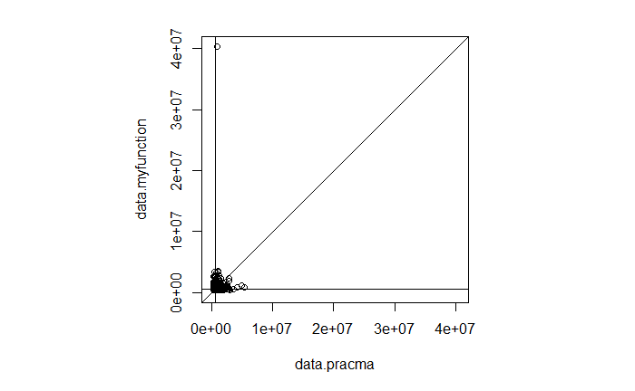

```r
abline(h = median.myfunction);
abline(v = median.pracma);
```

```r
# I have an "issue" with the default 'median' function, but for another time
```

DIMENISHING RETURNS… in this example … the efficiency improves as the CPU processes more of these (according to microbenchmark)

… I don’t think so…

# SIMULATION

You could wrap these code into a function, and pass a “times” parameter to build a table … A simulation of times ….

```r
library(microbenchmark);

benchmarkMe = function(N=100)
  {
  howMany = rand(50,100);
    # could I switch up the order?
  mb.res = microbenchmark::microbenchmark(
                                          pracma::primes(howMany) ,
                                          prime.pracmaPrimes(howMany),
                                          times = N
                                          );
  mb.res$which = as.numeric(mb.res$expr);
  data.pracma = subset(mb.res, which==1)$time;  # factors can't "==" on number
  data.myfunction = subset(mb.res, which==2)$time;

  myMax = max(c(data.pracma, data.myfunction));

  median.myfunction = median(data.myfunction);
  median.pracma = median(data.pracma);

  efficiencyB = abs(median.pracma - median.myfunction) / median.myfunction;
  efficiencyA = abs(median.pracma - median.myfunction) / median.pracma;

  # list(N=N, A=efficiencyA, B=efficiencyB);
  c(N, efficiencyA, efficiencyB);
  }
```

## Execute

```r
Ns = 10^(1:4);

res = NULL; # I don't know how big ... or do I?

for(N in Ns)
  {
  print(N);
  row = benchmarkMe(N);
  res = rbind(res, row);
  }
```

```
[1] 10
[1] 100
[1] 1000
[1] 10000
```

```r
res = data.frame(res);
rownames(res) = Ns;
colnames(res) = c("N", "efficiencyA", "efficiencyB");
res;
```

|  | N | efficiencyA | efficiencyB |
| --- | --- | --- | --- |
| 10 | 10 | 0.394774444 | 0.283038197 |
| 100 | 100 | 0.027254950 | 0.028018595 |
| 1000 | 1000 | 0.044558405 | 0.046636450 |
| 10000 | 10000 | 0.008439836 | 0.008511673 |

It seemed too fast … so … I don’t believe we are “clearing” CPU caching between either….

The RAM on this computer seems to be a bottleneck, the CPU was not maxed.

# Inverse functions

If you create a function, you should create its inverse. If it would exist.  
Often, when you are converting something, you will need to create a function to convert it back. This is good math(s) called a closed ALGEBRA.

```r
#' rgb2col
#'
#' Reverse the built-in grDevices::col2rgb function
#' [ See grDevices::convertColor or grDevices::make.rgb ]
```

# TODO: on your own

Following the PRIME example, can you build an efficiency table using SIMULATIONS comparing “rand” using the default “high/low” method from the very inefficient “sample” method.